# PhenoRec Tutorial: Phenotype-Preserving Integration of Paired Multimodal Data

In this tutorial, we demonstrate how to use **PhenoRec** for phenotype-preserving integration of paired single-cell RNA and antibody-derived tag (ADT) data, such as data generated by CITE-seq. Paired multimodal technologies jointly measure multiple molecular modalities in the same cells, providing complementary information about cell state.

Here, we use a publicly available COVID-19 CITE-seq dataset accessed from the [COVID-19 Cell Atlas](https://covid19cellatlas.org/). The dataset was generated in the study by [Stephenson et al.](https://www.nature.com/articles/s41591-021-01329-2), which profiled peripheral blood mononuclear cells (PBMCs) from healthy individuals and patients with COVID-19. COVID-19 severity was determined according to the WHO classification.

The tutorial consists of four main stages:

1. Preprocess the RNA and ADT data.
2. Estimate latent cell states.
3. Apply PhenoRec to recover phenotype-associated signals.
4. Visualize the phenotype-preserving integrated data.

# 1 Load required packages

We first load the packages required for this tutorial.

```r
library(PhenoRec)
library(Seurat)
library(anndata)
```

```r
library(ggplot2)
library(Matrix)
library(patchwork)
```

# 2 Load data

The dataset is stored in AnnData format (`.h5ad`) and is read into R using the `anndata` package.

```r
data <- read_h5ad(
  "../Multiome/CITE-COVID/covid_portal_210320_with_raw.h5ad"
)

metadata <- data$obs
var <- data$var
data_matrix <- data$layers[["raw"]]
```

In this file, RNA and ADT features are stored in the same feature matrix and distinguished by the `feature_types` annotation.

```r
gene_name <- rownames(var)[
  var$feature_types == "Gene Expression"
]

ADT_name <- rownames(var)[
  var$feature_types == "Antibody Capture"
]

length(gene_name)
```

```
## [1] 24737
```

```r
length(ADT_name)
```

```
## [1] 192
```

For this example, we retain cells from the `Ncl` site and from the `Healthy`, `Mild`, and `Severe` phenotype groups.

```r
head(metadata)
```

```
##                            sample_id n_genes n_genes_by_counts total_counts
## AAACCTGAGAAACCTA-MH9179824 MH9179824    1160              1160         2172
## AAACCTGAGAGTAATC-MH9179824 MH9179824    1419              1419         3947
## AAACCTGAGAGTGAGA-MH9179824 MH9179824    1986              1986         5886
## AAACCTGAGGAATCGC-MH9179824 MH9179824    1508              1508         4271
## AAACCTGAGTGTTGAA-MH9179824 MH9179824    1109              1109         2279
## AAACCTGCACCACGTG-MH9179824 MH9179824    1323              1323         3380
##                            total_counts_mt pct_counts_mt full_clustering
## AAACCTGAGAAACCTA-MH9179824              79      3.637201          CD8.TE
## AAACCTGAGAGTAATC-MH9179824              54      1.368128        CD4.IL22
## AAACCTGAGAGTGAGA-MH9179824             143      2.429494       CD8.Naive
## AAACCTGAGGAATCGC-MH9179824             106      2.481854       CD4.Naive
## AAACCTGAGTGTTGAA-MH9179824              76      3.334796          CD8.EM
## AAACCTGCACCACGTG-MH9179824              64      1.893491  CD83_CD14_mono
##                            initial_clustering Resample Collection_Day    Sex
## AAACCTGAGAAACCTA-MH9179824                CD8  Initial             D0 Female
## AAACCTGAGAGTAATC-MH9179824                CD4  Initial             D0 Female
## AAACCTGAGAGTGAGA-MH9179824                CD4  Initial             D0 Female
## AAACCTGAGGAATCGC-MH9179824                CD4  Initial             D0 Female
## AAACCTGAGTGTTGAA-MH9179824                CD4  Initial             D0 Female
## AAACCTGCACCACGTG-MH9179824               CD14  Initial             D0 Female
##                            Age_interval Swab_result Status     Smoker
## AAACCTGAGAAACCTA-MH9179824     (50, 59]    Positive  Covid Non-smoker
## AAACCTGAGAGTAATC-MH9179824     (50, 59]    Positive  Covid Non-smoker
## AAACCTGAGAGTGAGA-MH9179824     (50, 59]    Positive  Covid Non-smoker
## AAACCTGAGGAATCGC-MH9179824     (50, 59]    Positive  Covid Non-smoker
## AAACCTGAGTGTTGAA-MH9179824     (50, 59]    Positive  Covid Non-smoker
## AAACCTGCACCACGTG-MH9179824     (50, 59]    Positive  Covid Non-smoker
##                            Status_on_day_collection
## AAACCTGAGAAACCTA-MH9179824                  Ward_O2
## AAACCTGAGAGTAATC-MH9179824                  Ward_O2
## AAACCTGAGAGTGAGA-MH9179824                  Ward_O2
## AAACCTGAGGAATCGC-MH9179824                  Ward_O2
## AAACCTGAGTGTTGAA-MH9179824                  Ward_O2
## AAACCTGCACCACGTG-MH9179824                  Ward_O2
##                            Status_on_day_collection_summary Days_from_onset
## AAACCTGAGAAACCTA-MH9179824                         Moderate               8
## AAACCTGAGAGTAATC-MH9179824                         Moderate               8
## AAACCTGAGAGTGAGA-MH9179824                         Moderate               8
## AAACCTGAGGAATCGC-MH9179824                         Moderate               8
## AAACCTGAGTGTTGAA-MH9179824                         Moderate               8
## AAACCTGCACCACGTG-MH9179824                         Moderate               8
##                            Site time_after_LPS Worst_Clinical_Status Outcome
## AAACCTGAGAAACCTA-MH9179824  Ncl            nan              Moderate    Home
## AAACCTGAGAGTAATC-MH9179824  Ncl            nan              Moderate    Home
## AAACCTGAGAGTGAGA-MH9179824  Ncl            nan              Moderate    Home
## AAACCTGAGGAATCGC-MH9179824  Ncl            nan              Moderate    Home
## AAACCTGAGTGTTGAA-MH9179824  Ncl            nan              Moderate    Home
## AAACCTGCACCACGTG-MH9179824  Ncl            nan              Moderate    Home
##                            patient_id
## AAACCTGAGAAACCTA-MH9179824  MH9179824
## AAACCTGAGAGTAATC-MH9179824  MH9179824
## AAACCTGAGAGTGAGA-MH9179824  MH9179824
## AAACCTGAGGAATCGC-MH9179824  MH9179824
## AAACCTGAGTGTTGAA-MH9179824  MH9179824
## AAACCTGCACCACGTG-MH9179824  MH9179824
```

```r
metadata <- metadata[
  metadata$Site == "Ncl" &
    metadata$Status_on_day_collection_summary %in%
      c("Healthy", "Mild", "Severe"),
]

metadata$sample_id <- as.character(metadata$sample_id)
metadata$Status_on_day_collection_summary <-
  as.character(metadata$Status_on_day_collection_summary)
```

The metadata contain sample/batch identity (`sample_id`), phenotype information (`Status_on_day_collection_summary`), and cell-type annotations (`initial_clustering`).

For this tutorial, we randomly subsampled 100,000 cells for illustration purposes.

```r
set.seed(1)

sample_cells <- sample(
  rownames(metadata),
  100000
)

metadata <- metadata[
  sample_cells,
  ,
  drop = FALSE
]
```

We then extract the RNA and ADT matrices for the selected cells.

```r
rna_data <- data_matrix[
  rownames(metadata),
  gene_name
]

ADT_data <- data_matrix[
  rownames(metadata),
  ADT_name
]

dim(rna_data)
```

```
## [1] 100000  24737
```

```r
dim(ADT_data)
```

```
## [1] 100000    192
```

```r
stopifnot(
  identical(rownames(rna_data), rownames(ADT_data)),
  identical(rownames(rna_data), rownames(metadata))
)
```

At this stage, both matrices contain the same cells in the same order.

# 3 Create a multimodal Seurat object

We use the RNA counts to initialize a Seurat object and then add the ADT measurements as a second assay.

```r
seurat_data <- CreateSeuratObject(
  counts = t(rna_data),
  assay = "RNA",
  meta.data = metadata[rownames(rna_data), ]
)
seurat_data[["ADT"]] <- CreateAssayObject(
  counts = t(ADT_data)
)
seurat_data
```

```
## An object of class Seurat
## 24929 features across 1e+05 samples within 2 assays
## Active assay: RNA (24737 features, 0 variable features)
##  1 layer present: counts
##  1 other assay present: ADT
```

The Seurat object now contains two assays:

- `RNA` for gene-expression measurements; and
- `ADT` for surface-protein measurements.

# 4 Preprocess the RNA modality

We first process the RNA measurements using the standard Seurat workflow. If you are unfamiliar with this workflow, please refer to their official tutorial.

```r
DefaultAssay(seurat_data) <- "RNA"

seurat_data <- NormalizeData(
  seurat_data
)
```

```
## Normalizing layer: counts
```

```r
seurat_data <- FindVariableFeatures(
  seurat_data,
  nfeatures = 3000
)
```

```
## Finding variable features for layer counts
```

```r
seurat_data <- ScaleData(
  seurat_data
)
seurat_data <- RunPCA(
  seurat_data,
  features = VariableFeatures(seurat_data),
  npcs = 200,
  verbose = FALSE
)
```

Here, 3,000 highly variable genes are selected, and PCA is used to obtain a lower-dimensional representation.

We construct an RNA UMAP using the first 50 principal components.

```r
seurat_data <- RunUMAP(
  seurat_data,
  dims = 1:50,
  reduction = "pca",
  reduction.name = "umap_rna",
  reduction.key = "rnaUMAP_"
)
```

The UMAP embedding can be colored by cell type, sample, and phenotype.

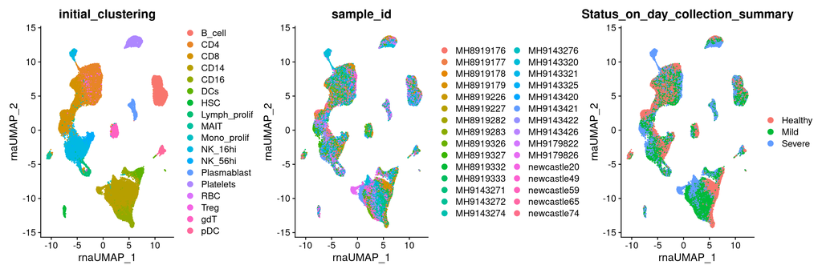

```r
p_rna_celltype <- DimPlot(
  seurat_data,
  reduction = "umap_rna",
  group.by = "initial_clustering"
)

p_rna_batch <- DimPlot(
  seurat_data,
  reduction = "umap_rna",
  group.by = "sample_id"
)

p_rna_pheno <- DimPlot(
  seurat_data,
  reduction = "umap_rna",
  group.by = "Status_on_day_collection_summary"
)

p_rna_celltype + p_rna_batch + p_rna_pheno
```

# 5 Preprocess the ADT modality

We next process the ADT measurements. ADT counts are normalized using centered log-ratio (CLR) normalization, followed by scaling and PCA.

```r
DefaultAssay(seurat_data) <- "ADT"

seurat_data <- NormalizeData(
  seurat_data,
  normalization.method = "CLR",
  margin = 2,
  verbose = FALSE
)

seurat_data <- ScaleData(
  seurat_data,
  features = rownames(seurat_data),
  verbose = FALSE
)

seurat_data <- RunPCA(
  seurat_data,
  features = rownames(seurat_data),
  reduction.name = "apca",
  reduction.key = "APC_",
  npcs = 30,
  verbose = FALSE
)
```

The ADT PCA is stored as the dimensional reduction `apca`. We construct an ADT UMAP using all 30 ADT principal components.

```r
seurat_data <- RunUMAP(
  seurat_data,
  dims = 1:30,
  reduction = "apca",
  reduction.name = "umap_adt",
  reduction.key = "adtUMAP_"
)
```

```
## 02:42:37 1353 smooth knn distance failures
```

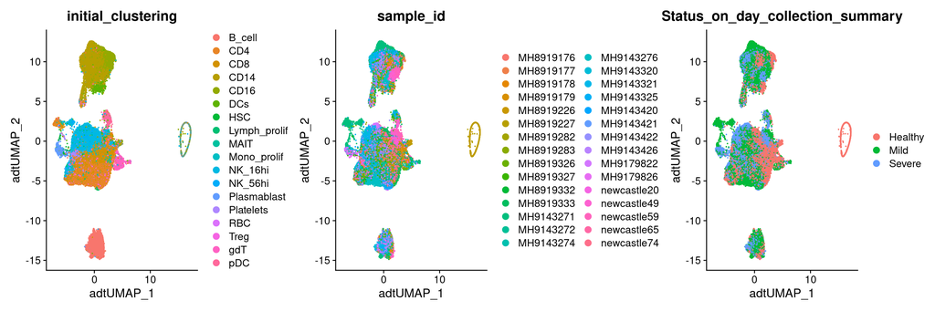

```r
p_adt_celltype <- DimPlot(
  seurat_data,
  reduction = "umap_adt",
  group.by = "initial_clustering"
)

p_adt_batch <- DimPlot(
  seurat_data,
  reduction = "umap_adt",
  group.by = "sample_id"
)

p_adt_pheno <- DimPlot(
  seurat_data,
  reduction = "umap_adt",
  group.by = "Status_on_day_collection_summary"
)

p_adt_celltype + p_adt_batch + p_adt_pheno
```

# 6 Visualize the unintegrated joint multimodal representation

Because RNA and ADT are measured in the same cells, they can be combined using Seurat’s weighted nearest neighbor (WNN) framework.

```r
options(future.globals.maxSize = 2 * 1024^3)

seurat_data <- FindMultiModalNeighbors(
  seurat_data,
  reduction.list = list("pca", "apca"),
  dims.list = list(1:50, 1:30)
)
```

```
## Calculating cell-specific modality weights
```

```
## Finding 20 nearest neighbors for each modality.
```

```
## Calculating kernel bandwidths
```

```
## Finding multimodal neighbors
```

```
## Constructing multimodal KNN graph
```

```
## Constructing multimodal SNN graph
```

```r
seurat_data <- RunUMAP(
  seurat_data,
  nn.name = "weighted.nn",
  reduction.name = "wnn.umap",
  reduction.key = "wnnUMAP_"
)
```

```
## 02:49:04 1251 smooth knn distance failures
```

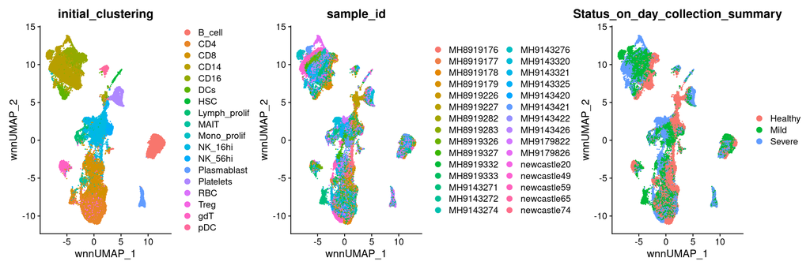

```r
p_wnn_celltype <- DimPlot(
  seurat_data,
  reduction = "wnn.umap",
  group.by = "initial_clustering"
)

p_wnn_batch <- DimPlot(
  seurat_data,
  reduction = "wnn.umap",
  group.by = "sample_id"
)

p_wnn_pheno <- DimPlot(
  seurat_data,
  reduction = "wnn.umap",
  group.by = "Status_on_day_collection_summary"
)

p_wnn_celltype + p_wnn_batch + p_wnn_pheno
```

This WNN embedding provides a useful visualization of the joint RNA + ADT measurements.

# 7 Estimate latent cell states

PhenoRec first requires an estimate of the underlying cell-state representation, denoted by (Z) in the PhenoRec model. In the current workflow, conventional integration with Harmony is used to obtain this representation.

For paired multimodal data, we estimate cell states separately for RNA and ADT because the two modalities have different feature spaces and preprocessing procedures.

## 7.1 RNA latent cell states

Harmony is applied to the RNA PCA representation using `sample_id` as the batch variable.

```r
rna_z <- harmony::RunHarmony(
  Embeddings(seurat_data, "pca"),
  seurat_data[[]],
  "sample_id"
)
```

```
## Transposing data matrix
```

```
## Initializing state using k-means centroids initialization
```

```
## Harmony 1/10
```

```
## Harmony 2/10
```

```
## Harmony 3/10
```

```
## Harmony converged after 3 iterations
```

```r
seurat_data[["rna_z"]] <- CreateDimReducObject(
  embeddings = rna_z,
  key = "RNAZ_",
  assay = "RNA"
)
```

## 7.2 ADT latent cell states

Harmony is then applied independently to the ADT PCA representation.

```r
adt_z <- harmony::RunHarmony(
  Embeddings(seurat_data, "apca"),
  seurat_data[[]],
  "sample_id"
)
```

```
## Transposing data matrix
```

```
## Initializing state using k-means centroids initialization
```

```
## Harmony 1/10
```

```
## Harmony 2/10
```

```
## Harmony 3/10
```

```
## Harmony 4/10
```

```
## Harmony converged after 4 iterations
```

```r
seurat_data[["adt_z"]] <- CreateDimReducObject(
  embeddings = adt_z,
  key = "ADTZ_",
  assay = "ADT"
)
```

The resulting reductions, `rna_z` and `adt_z`, provide modality-specific estimates of latent cell states.

# 8 Encode batch and phenotype information

PhenoRec requires encoded matrices of categorical batch and phenotype variables. These are generated using `encoding_function()`.

```r
encoding_data <- encoding_function(
  seurat_data = seurat_data,
  batch_id = "sample_id",
  phenotype_id = "Status_on_day_collection_summary"
)
```

# 9 Run PhenoRec on the RNA modality

We now apply PhenoRec to the RNA data.

```r
seurat_data[["estimate_z"]] <- seurat_data[["rna_z"]]
input_data <- list(
  rna_data = seurat_data,
  encoding_data = encoding_data
)

PhenoRec_rna_result <- PhenoRec_RNA(
  input = input_data
)
```

```
## PhenoRec completed.
```

```r
integrated_rna_data <-
  PhenoRec_rna_result$integrated_data

dim(integrated_rna_data)
```

```
## [1] 100000   3000
```

`integrated_rna_data` is the PhenoRec-recovered RNA data. In the current workflow, cells are represented by rows and genes by columns. The recovered data removes unwanted batch variation while preserving biologically meaningful phenotype-associated variation.

# 10 Run PhenoRec on the ADT modality

We then repeat the procedure for the ADT data

```r
seurat_data[["estimate_z"]] <- seurat_data[["adt_z"]]
input_data <- list(
  adt_data = seurat_data,
  encoding_data = encoding_data
)

PhenoRec_adt_result <- PhenoRec_ADT(
  input = input_data
)
```

```
## PhenoRec completed.
```

```r
integrated_adt_data <-
  PhenoRec_adt_result$integrated_data

dim(integrated_adt_data)
```

```
## [1] 100000    192
```

`integrated_adt_data` contains the corresponding PhenoRec-recovered ADT data, with cells represented by rows and ADT features by columns.

# 11 Construct a PhenoRec-integrated multimodal Seurat object

We now create a new Seurat object containing the recovered RNA and ADT data.

## 11.1 Add the recovered RNA data

The PhenoRec RNA output is transposed so that features are rows and cells are columns, as expected by Seurat.

```r
integrated_rna_assay <- CreateAssayObject(
  data = t(integrated_rna_data)
)

integrated_obj <- CreateSeuratObject(
  counts = integrated_rna_assay,
  assay = "RNA",
  meta.data = seurat_data[[]]
)
```

We scale the recovered RNA values and compute PCA.

```r
DefaultAssay(integrated_obj) <- "RNA"

integrated_obj <- ScaleData(
  integrated_obj
)
integrated_obj <- RunPCA(
  integrated_obj,
  features = rownames(integrated_obj)
)
```

```
## PC_ 1
## Positive:  IL32, CD7, LTB, IL7R, CTSW, TRBC1, CD69, RPLP0, KLRK1, CD27
##     MT-CYB, SH2D2A, KLRB1, CAMK4, CST7, FKBP11, GZMA, CCL5, NCR3, KLRD1
##     PRDX2, PRF1, TCF7, MATK, EEF1A1, GNLY, PIM2, KLRG1, TRAT1, LEF1
## Negative:  IFI30, SPI1, GRN, SERPINA1, NCF2, FCN1, CFP, TNFSF13B, CTSS, CST3
##     LST1, LGALS3, LILRB2, PSAP, FCGRT, AIF1, IGSF6, LILRA5, PYCARD, TYMP
##     CYBB, MNDA, CFD, CD68, FTL, CLEC7A, SAT1, PILRA, BLVRB, MAFB
## PC_ 2
## Positive:  RPS4Y1, IGKV2OR22-4, SCNN1B, DDX3Y, CXCL13, IGHJ2, AC084809.1, AHSP, KCNG1, FBXO17
##     AC005307.1, IGKV2D-24, EIF1AY, TRDV2, RHBDL3, AL583722.3, TRGV9, EGOT, AC008825.1, TRGV11
##     CD207, SORCS3, KIF24, CEACAM3, KLRC1, HCG20, AC104073.4, TRAC, NMU, FAM3B
## Negative:  TNFRSF17, CAV1, XIST, GPRC5D, IGKV3OR2-268, TXNDC5, TSHR, MYOM2, GLDC, IGHJ3
##     IGF1, IGLC1, AC106897.1, RPS10, IGHV6-1, KCNN3, GSTM1, AL133467.1, CBWD1, PYCR1
##     CRYBB1, LINC01055, MZB1, LINC02362, PARM1, BUB1, SDC1, JCHAIN, NCAPG, LINC01484
## PC_ 3
## Positive:  TNNI3, AC012507.1, EEF1A1, LINC00853, AC093627.6, AL954642.1, RPLP0, AP001189.1, GLYATL2, AP001189.3
##     CRIP1, GSTA1, MIF, LINC01228, PPIB, MESTIT1, MT-CO1, HSP90AA1, PVALB, MT-CO3
##     AC010737.1, CFAP161, HSP90B1, ANXA1, RPS4Y1, SPANXN4, AC005381.1, MT-ND6, RAN, S100A4
## Negative:  TSC22D1, GP9, ESAM, AP003068.2, GP1BA, CAVIN2, TUBB1, PTGS1, CMTM5, PF4
##     TMEM40, CLEC1B, MPIG6B, FAXDC2, GNG11, LGALS12, C2orf88, PPBP, RGS18, AC123912.4
##     TRIM58, PDGFA, SPARC, MYLK, SCN1B, SNCA, GMPR, PLA2G12A, ITGB3, CLDN5
## PC_ 4
## Positive:  ZNF385D, IGLL1, TMEM98, BCL6B, CHRM3, NPR3, AF233439.1, SCHIP1, CYTL1, MEX3B
##     CCDC181, RHEX, CD34, MED12L, GCSAML, HOXA10-AS, SLC45A3, CMBL, PTPRD, RAC3
##     CNKSR3, ZNF99, BEX1, AC246787.2, PRSS57, CAVIN1, PROM1, SMIM10, CRHBP, HOXA7
## Negative:  ZSCAN1, CDH9, LINC01229, TPSB2, AC128709.2, LINC01731, HMGA2, FSTL4, THRSP, MNS1
##     KBTBD12, CLC, ALAS2, AL590226.1, IFI44L, IFI6, IGHV3-72, IGHVII-44-2, AC084125.4, TGM5
##     AC100849.1, ISG15, NECAB1, IFI27, NPPC, AADAT, CES3, ISG20, OASL, GAP43
## PC_ 5
## Positive:  NKG7, GZMA, CST7, CTSW, CD7, MATK, PRF1, KLRK1, KLRD1, GNLY
##     SH2D2A, KLRB1, IFITM2, ANXA1, HOPX, TRBC1, NUF2, MT2A, CCL4, KLRF1
##     SPON2, TYMS, ACTB, S1PR5, UHRF1, CCL5, RRM2, ZWINT, S100A4, GZMH
## Negative:  CD79A, RALGPS2, IGHM, MS4A1, BLNK, LINC00926, AFF3, TCF4, HLA-DQA1, SPIB
##     BANK1, CD79B, CD19, BLK, FCRLA, HLA-DOB, COBLL1, IGHD, RUBCNL, MEF2C
##     FCRL1, TNFRSF13C, LCN8, CD22, IRF8, PAX5, CD74, PNOC, VPREB3, P2RX5
```

## 11.2 Add the recovered ADT data

We add the PhenoRec-recovered ADT matrix as a second assay.

```r
integrated_obj[["ADT"]] <- CreateAssayObject(
  data = t(integrated_adt_data)
)
DefaultAssay(integrated_obj) <- "ADT"

integrated_obj <- ScaleData(
  integrated_obj
)
integrated_obj <- RunPCA(
  integrated_obj,
  features = rownames(integrated_obj),
  npcs = 30,
  reduction.name = "adt_pca"
)
```

```
## PC_ 1
## Positive:  AB-FASLG, AB-SDC1, AB-phosphoTau, AB-CDH1, AB-KIR2DL5A, AB-TCR-Va24-Ja18, AB-XCR1, AB-TNFRSF17, AB-LAG3, AB-CD96
##     AB-FCRL4, AB-TIGIT, AB-CD70, AB-CD40LG, AB-PD1, AB-GITR, AB-CD80, AB-MSR1, AB-TCRg-d, AB-CCR7
##     AB-NLRP2, AB-TNFRSF8, AB-LGALS3, AB-NCR2, AB-CD209, AB-IL2RB, AB-CD303, AB-TNFRSF9, AB-BAFF, AB-podoplanin
## Negative:  AB-FCGR2A, AB-SIGLEC7, AB-CD33, AB-ITGAX, AB-CLEC12A, AB-CR1, AB-ENTPD1, AB-CD86, AB-CD64, AB-LAIR1
##     AB-ITGB2, AB-CD36, AB-ICAM1, AB-PECAM1, AB-ITGAM, AB-CEACAM1/5/6, AB-CD44, AB-HLA-DR, AB-LILRB1, AB-Igkappa
##     AB-CD14, AB-CD101, AB-ITGAL, AB-HLA-ABC, AB-CD21, AB-GGT1, AB-HLA-A-2, AB-ITGB1, AB-CD71, AB-SLC3A2
## PC_ 2
## Positive:  AB-PVR, AB-GGT1, AB-ITGAM, AB-CLEC12A, AB-CD14, AB-CD36, AB-PECAM1, AB-CD33, AB-FAS, AB-CD64
##     AB-CD101, AB-ITGAX, AB-LILRB1, AB-C5AR1, AB-ICAM1, AB-LAIR1, AB-ITGAL, AB-SIGLEC7, AB-CD86, AB-ITGB2
##     AB-ITGB1, AB-CD244, AB-CX3CR1, AB-CD44, AB-CD58, AB-CR1, AB-SLC3A2, AB-Igkappa, AB-CD1d, AB-CD99
## Negative:  AB-CD21, AB-CD20, AB-CD19, AB-IgD, AB-IgM, AB-CXCR5, AB-BAFFR, AB-CD45RA, AB-CCR6, AB-BTLA
##     AB-CD40, AB-CEACAM1/5/6, AB-VCAM1, AB-CD22, AB-CTLA4, AB-CD62L, AB-CD81, AB-NT5E, AB-CD7, AB-CD79b
##     AB-TCR-Vg2, AB-TACI, AB-CD5, AB-CD3, AB-HLA-A-2, AB-KLRD1, AB-CD27, AB-IgA, AB-KLRK1, AB-TCR
## PC_ 3
## Positive:  AB-CD7, AB-CEACAM1/5/6, AB-CD2, AB-CD3, AB-KLRD1, AB-VCAM1, AB-CD56, AB-CD226, AB-CTLA4, AB-KLRG1
##     AB-ITGA6, AB-CD5, AB-Mouse-IgG2b-K-Iso, AB-CD16, AB-CD244, AB-IL7R, AB-THY1, AB-B3GAT1, AB-TCR-Vg2, AB-FAS
##     AB-CD28, AB-CD8, AB-ICOS, AB-CCR4, AB-HAVCR2, AB-CD96, AB-ITGAL, AB-TACI, AB-CD38, AB-CD4
## Negative:  AB-Iglambda, AB-BAFFR, AB-CD19, AB-CD20, AB-CD21, AB-CD40, AB-CD22, AB-CXCR5, AB-CCR6, AB-IgM
##     AB-IgD, AB-FCGR2A, AB-BTLA, AB-HLA-DR, AB-CD52, AB-Igkappa, AB-ENTPD1, AB-CR1, AB-CD79b, AB-CD82
##     AB-NT5E, AB-HLA-ABC, AB-IgA, AB-CD24, AB-LILRB1, AB-RANKL, AB-KIT, AB-CD45, AB-HLA-F, AB-LAIR1
## PC_ 4
## Positive:  AB-CD45, AB-CD5, AB-CD4, AB-CD3, AB-CD2, AB-CD52, AB-CD44, AB-TCR, AB-IL7R, AB-CD28
##     AB-CD47, AB-CD62L, AB-CD27, AB-DPP4, AB-CD99, AB-ICOS, AB-CD82, AB-CD45RO, AB-CD8, AB-ITGA4
##     AB-FAS, AB-CD101, AB-ITGAL, AB-ITGB7, AB-PD1, AB-CD81, AB-FCER2, AB-ITGB2, AB-CCR4, AB-CD303
## Negative:  AB-CCR3, AB-CD274, AB-Podocalyxin, AB-CD38, AB-langerin, AB-LIGHT, AB-LRRC32, AB-ICOSLG, AB-TCR-VB-13-1, AB-CD158
##     AB-SLAMF7, AB-CD1d, AB-CD56, AB-CD16, AB-LAMP1, AB-TNFSF9, AB-CLEC9A, AB-CD69, AB-ITGA2, AB-NCR1
##     AB-SELP, AB-CD244, AB-CXCR3, AB-EPCAM, AB-KIR3DL1, AB-CEACAM8, AB-SLC3A2, AB-IL21R, AB-TCR-Vg9, AB-ITGA2B
## PC_ 5
## Positive:  AB-LRRC32, AB-CD274, AB-ITGA6, AB-GGT1, AB-CCR3, AB-ITGA2, AB-CD4, AB-ITGA2B, AB-SELP, AB-IL7R
##     AB-CD5, AB-TCR-VB-13-1, AB-Mouse-IgG2b-K-Iso, AB-langerin, AB-CD27, AB-ITGB1, AB-CCR4, AB-ICOSLG, AB-CD69, AB-LIGHT
##     AB-CD3, AB-DPP4, AB-ICOS, AB-Podocalyxin, AB-CD45RO, AB-CXCR3, AB-TNFSF9, AB-CEACAM8, AB-CD28, AB-LAMP1
## Negative:  AB-CD16, AB-CD244, AB-CD56, AB-CD45RA, AB-NCR1, AB-KLRD1, AB-CD158b, AB-KIR3DL1, AB-IL2RB, AB-B7-H4
##     AB-B3GAT1, AB-CX3CR1, AB-ITGA4, AB-ITGAL, AB-CD38, AB-PD1, AB-MMR, AB-CD209, AB-PROM1, AB-CD7
##     AB-NCR3, AB-CD161, AB-Mouse IgG1-K-Iso, AB-TNFRSF8, AB-FCER2, AB-LAIR1, AB-PTGDR2, AB-CD99, AB-SIGLEC7, AB-MSR1
```

The new object therefore contains modality-specific low-dimensional representations derived from the phenotype-preserving PhenoRec outputs.

# 12 Build the phenotype-preserving joint multimodal representation

Finally, we combine the recovered RNA and ADT representations using WNN.

```r
integrated_obj <- FindMultiModalNeighbors(
  integrated_obj,
  reduction.list = list("pca", "adt_pca"),
  dims.list = list(1:50, 1:30)
)
```

```
## Calculating cell-specific modality weights
```

```
## Finding 20 nearest neighbors for each modality.
```

```
## Calculating kernel bandwidths
```

```
## Finding multimodal neighbors
```

```
## Constructing multimodal KNN graph
```

```
## Constructing multimodal SNN graph
```

```r
integrated_obj <- RunUMAP(
  integrated_obj,
  nn.name = "weighted.nn",
  reduction.name = "wnn.umap",
  reduction.key = "wnnUMAP_"
)
```

We visualize the resulting joint representation by cell type, sample, and phenotype.

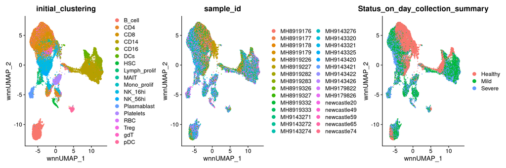

```r
p_integrated_celltype <- DimPlot(
  integrated_obj,
  reduction = "wnn.umap",
  group.by = "initial_clustering"
)

p_integrated_batch <- DimPlot(
  integrated_obj,
  reduction = "wnn.umap",
  group.by = "sample_id"
)

p_integrated_pheno <- DimPlot(
  integrated_obj,
  reduction = "wnn.umap",
  group.by = "Status_on_day_collection_summary"
)

p_integrated_celltype +
  p_integrated_batch +
  p_integrated_pheno
```

The PhenoRec-integrated WNN representation combines information from both recovered modalities. A successful phenotype-preserving integration should reduce unwanted batch variation while retaining biologically meaningful phenotype-associated variation. This representation can be used to identify cell populations exhibiting pronounced state changes across phenotypes.